# Bayes vs Credibility

Pedro Ecija Serrano

14 March 2016

# Start

Installing the package with the insurance data we will use. We are interested in the ‘dataCar’ dataset

```r
  library(MASS) #Useful to fit statistical distributions
  library(insuranceData)
  #This package comes with the following datasets:
  #AutoBi: US motor insurance claims
  #AutoClaims: US motor insurance claims
  #AutoCollision: UK motor insurance claims data
  #ClaimsLong: simulated motor insurance book (policies and claims)
  #dataCar: motor insurance claims data
  #dataOhlson: Sweedish motorcycle insurance claims data
  #IndustryAuto: US motor insurance claims triangle
  #SingaporeAuto: Singaporean motor insurance claims data
  #ThirdParty: Australian motor insurance claims data
  #WorkersComp: Workers Compensation claims data

  library(dplyr)
```

```r
  library(ggplot2)
  data(dataCar)
```

## Number of Claims

The dataset represents the total population and our assumption is that the claims and loss distributions followed seen in the population are available as a market index.

We will also assume that an insurance company is targetting women but has no data regarding how women’s claims experience may differ from the population’s.

The company could follow a Bayesian approach and consider the population’s distributions as priors and develop a posterior distribution with any claims experience gained during operations.

The insurer could also follow an actuarial approach and use credibility theory to develop its own distributions.

We will try both and compare results.

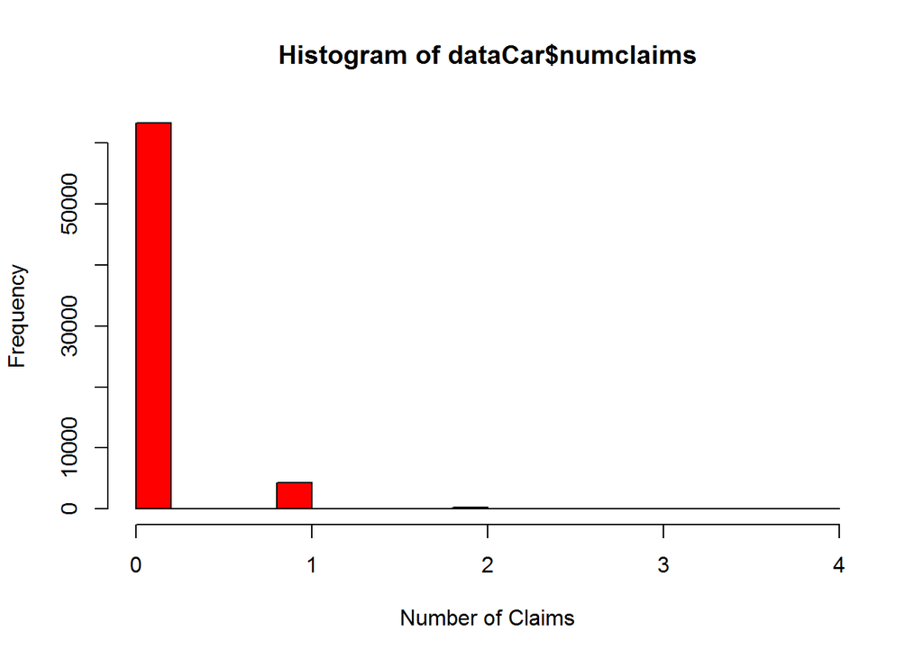

```r
  hist(dataCar$numclaims, col='red', xlab = 'Number of Claims')
```

```r
  popclaimsn <- sum(dataCar$numclaims) #Total number of claims in the dataset
  popsize <- nrow(dataCar) #Size of the dataset
  popmean <- mean(dataCar$numclaims) #Mean
  popvar <- var(dataCar$numclaims) #Variance
```

The shape of the histogram, together with the similarity between the mean (0.0728) and the variance (0.0774), indicate that the population’s number of claims may be a Poisson distributed.

Let’s create a subset with only female drivers. This is the market the insurance company is targetting and whose distribution we ignore.

We will also create a random sample from this subset, which will be the company’s policyholders (I arbitrarily choose a third of all female drivers).

```r
  set.seed(600)
  nsample <- 1/3
  femdata <- filter(dataCar, gender=='F')
  femsample <- sample_n(femdata, round(nsample*nrow(femdata),0), replace=FALSE)
```

There are 38603 rows in the dataset and the company’s portfolio has 12868 policyholders.

### Bayesian approach to number of claims

Here we will see how a Bayesian approach, taking the population’s distribution for the number of claims as prior distribution, produces a posterior distribution based on the data from the company’s policyholders.

The Poisson’s conjugate prior is a Gamma distribution with two parameters: shape and rate. Shape equals the number of claims and rate equals the number of observations.

We know there are 4937 in a population of 67856 policies. This means our prior parameters are: scale = 4937 and rate = 67856.

These parameters will be udpated with the claims experience arising from the company’s book.

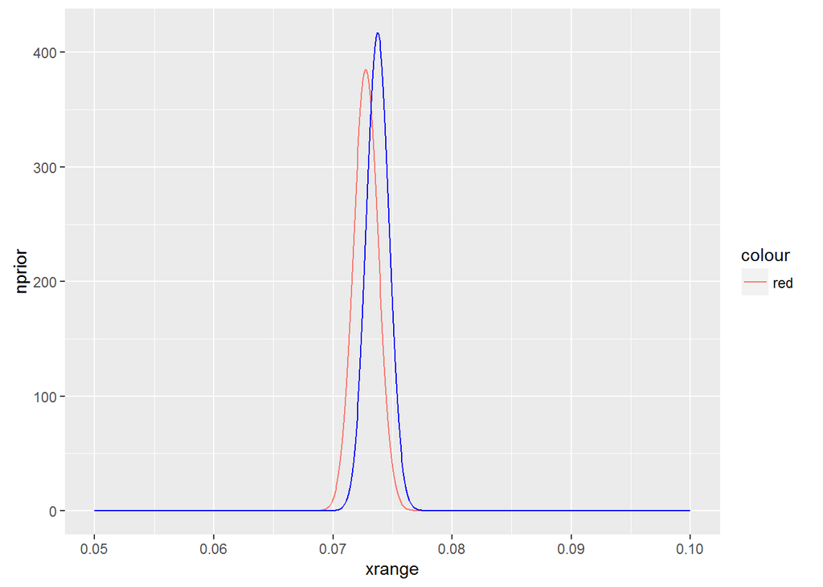

```r
  #Prior distribution
  xrange <- seq(0.05,0.1,0.0001)
  alpha <- popclaimsn #Shape
  beta <- popsize #Size
  nprior <- dgamma(xrange, shape=alpha, rate=beta)

  #Posterior distribution
  alpha.star <- alpha + sum(femsample$numclaims)
  beta.star <- beta + nrow(femsample)
  nposterior <- dgamma(xrange, shape = alpha.star, rate=beta.star)

  qplot(xrange, nprior, geom='line', color='red')+geom_line(aes(xrange, nposterior), color='blue')
```

The red line shows the prior conjugate, a gamma with parameters based on the population. The blue line shows how this distribution has been affected with the data: the mean has shifted slightly to the right and the density of probability seems a little narrower, indicating more certainty over the estimated parameter.

In terms of variance, the numbers are so small that we are better off comparing the log of the variance: the variance based on the population was -13.745773 and the variance based on the posterior distribution is -13.9059318

### Credibility approach to number of claims

Credibility theory allows for the combination of old and new information with the use of a credibility factor. This factor measures the strength of our belief in the new data so that the estimated parameter. In our case we try to estimate the mean and variance of a Poisson distribution.

Credibility theory says that the new parameter is given by the following expresion: $\lambda' = \lambda^{*}*z + \lambda * (1-z)$ Where $\lambda'$ is the parameter we will use, $lambda$ is the original parameter from the population’s distribution and $lambda^{*}$ is the parameter solely based on the company’s portfolio.

The credibility factor z is calculated as: $z = \sqrt (n/N)$ Where n is the size of the portfolio and N is the size of the population. We could use other magnitudes such as written premium rather than size, etc but it appears appropriate in this case and we do not really have much else to use.

```r
  lambda <- popmean
  lambda.star <- mean(femsample$numclaims)
  z <- sqrt(nrow(femsample)/popsize)
  lambda.comma <- lambda.star * z + lambda * (1-z)
```

The result is 0.0755.

Let’s find a better way to compare the results we have:

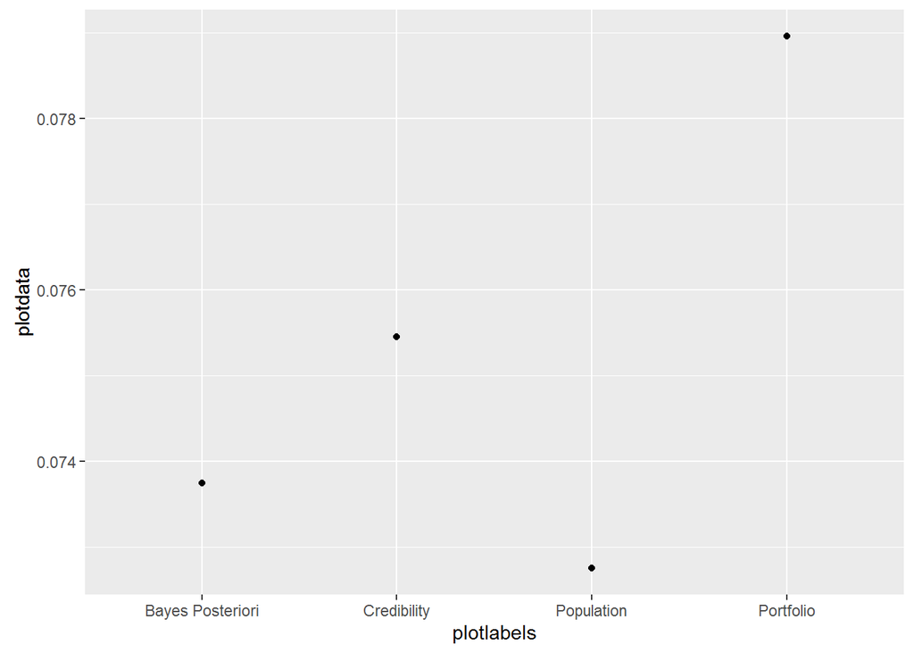

```r
  plotdata <- c(popmean, alpha.star/beta.star, lambda.comma, lambda.star)
  plotlabels <- c('Population', 'Bayes Posteriori', 'Credibility', 'Portfolio')
  qplot(x=plotlabels, y=plotdata, geom='point')
```

## Claims Cost

We can follow a similar process to come out with an estimate for the company’s average claims cost. Let us see first what the population’s distribution looks like:

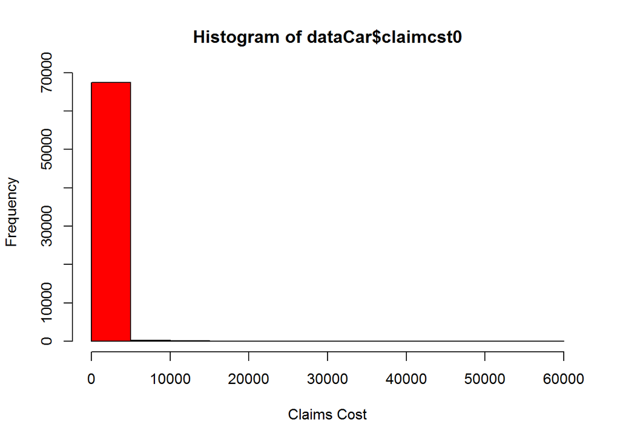

```r
  hist(dataCar$claimcst0, col='red', xlab = 'Claims Cost')
```

It is hard to notice much so let’s try a density plot:

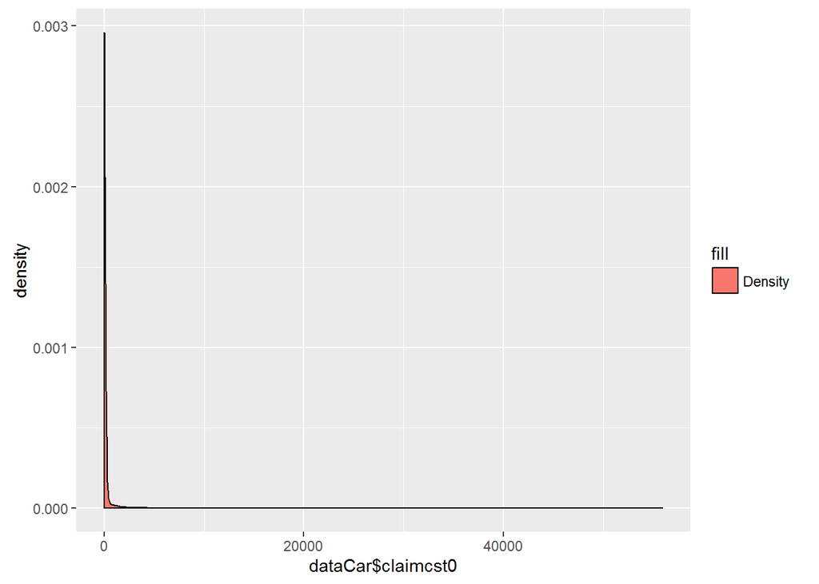

```r
  qplot(dataCar$claimcst0, geom='density', fill='Density')
```

The packages ‘fitdistrplus’ has many useful functions to fit statistical distributions so we will try some now.

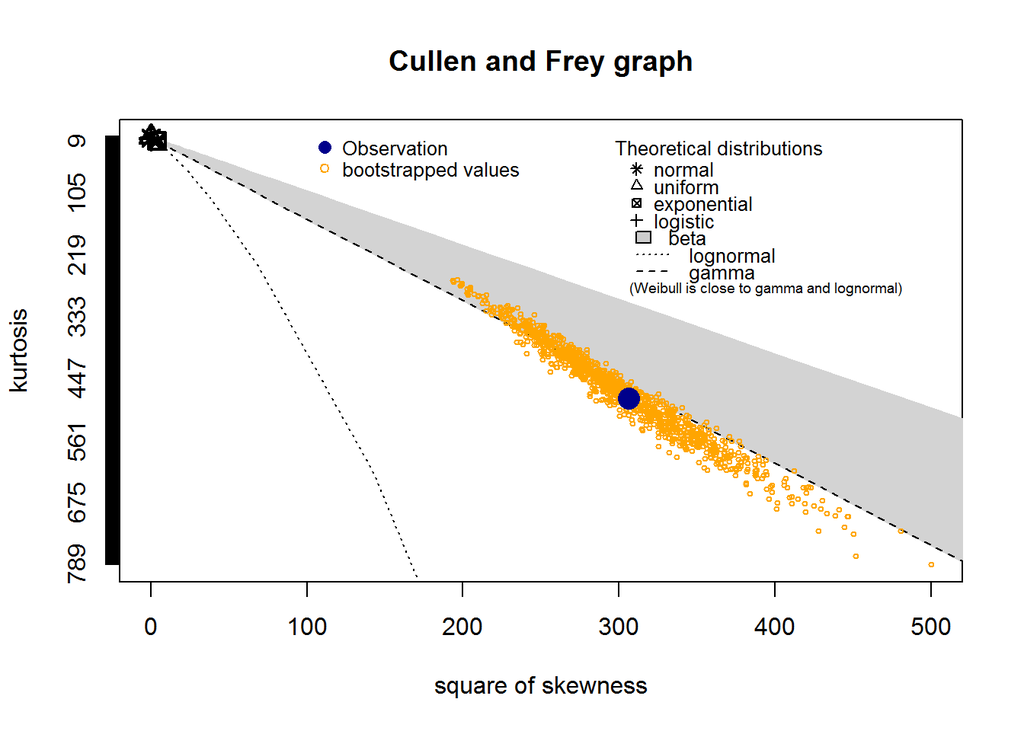

```
## summary statistics
## ------
## min:  0   max:  55922.13
## median:  0
## mean:  137.2702
## estimated sd:  1056.298
## estimated skewness:  17.5025
## estimated kurtosis:  482.9257
```

```r
  library(fitdistrplus) #This packages has useful functions to fit statistical distributions.
  #cprior<- fitdistr(dataCar$claimcst0, "exponential")
  descdist(dataCar$claimcst0, boot=1000)
```

```r
  #The optional boot parameter is used apply a non-parametric bootstrap procedure to take into account the uncertainty in the estimates for skewness and kurtosis, which are known not to be robust.
```

The Cullen and Frey graph suggest that a Gamma should be our best approach to model the distribution of claim costs. However, the Gamma is not defined for zero values and we have plenty of them!

The next best solution would be a beta but this is defined only for values between zero and one.

After that, we should be looking at a lognormal, even if we already know it is not the ideal fit but, again, the lognormal never takes the value of zero.

We have to try separating the observations where there have been no claims and see if that removes the zeroes in the claims cost.

```r
  CarClaims <- filter(dataCar, numclaims >0)
  summary(CarClaims$claimcst0)
```

```
##    Min. 1st Qu.  Median    Mean 3rd Qu.    Max.
##   200.0   353.8   761.6  2014.0  2091.0 55920.0
```

That has done the trick but we need to review what the claim cost distribution looks like after that change.

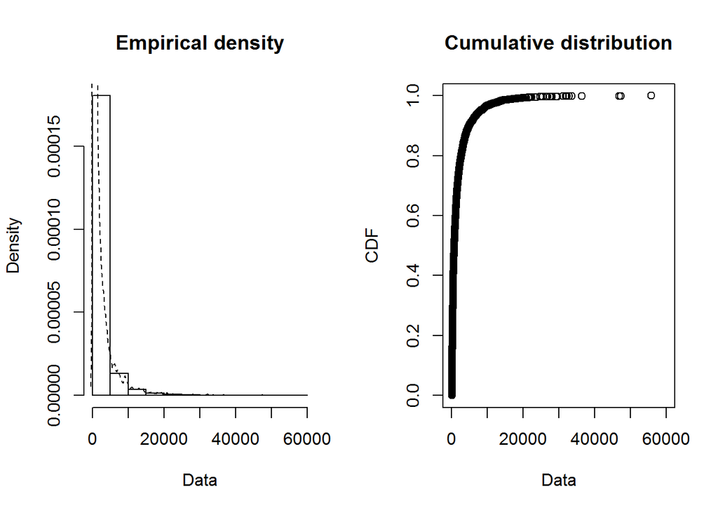

```r
  plotdist(CarClaims$claimcst0, histo=TRUE, demp=TRUE)
```

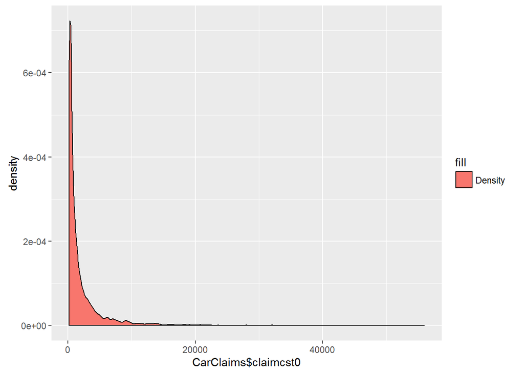

```r
  qplot(CarClaims$claimcst0, geom='density', fill='Density')
```

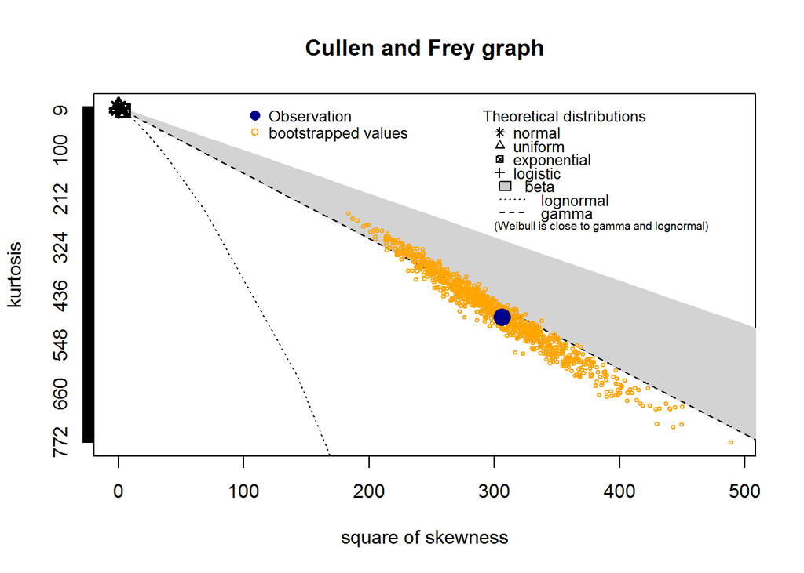

```
## summary statistics
## ------
## min:  0   max:  55922.13
## median:  0
## mean:  137.2702
## estimated sd:  1056.298
## estimated skewness:  17.5025
## estimated kurtosis:  482.9257
```

```r
  descdist(dataCar$claimcst0, boot=1000)
```

```r
  cprior <- fitdist(CarClaims$claimcst0, 'gamma', lower=c(0.01,0.01))
  #We use 'lower=c(0.01,0.01)' to force fitdist use non-negative values.
  summary(cprior)
```

```
## Fitting of the distribution ' gamma ' by maximum likelihood
## Parameters :
##       estimate   Std. Error
## shape 9.564851 0.1748678984
## rate  0.010000 0.0001858036
## Loglikelihood:  -81828.96   AIC:  163661.9   BIC:  163674.8
## Correlation matrix:
##           shape      rate
## shape 1.0000000 0.9673808
## rate  0.9673808 1.0000000
```

```r
  gofstat(cprior)
```

```
## Goodness-of-fit statistics
##                              1-mle-gamma
## Kolmogorov-Smirnov statistic   0.3568693
## Cramer-von Mises statistic   208.8744765
## Anderson-Darling statistic           Inf
##
## Goodness-of-fit criteria
##                                1-mle-gamma
## Aikake's Information Criterion    163661.9
## Bayesian Information Criterion    163674.8
```

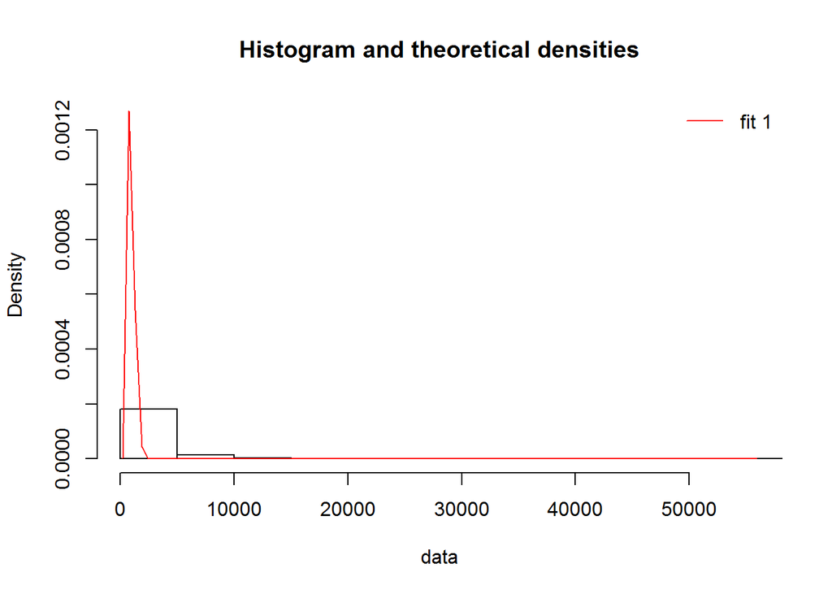

```r
  denscomp(cprior)
```

The plot above is not very promising given how the plotted density of the fitted gamma compares with the data histogram. We will have to try something less clever and more exhaustive. I will fit the following distributions and compare results: a gamma (we already have it), a lognormal, a Weibull, a Pareto and a Loglogistic.

```r
  library(actuar) #Here we can find the Pareto distribution
  cpGamma <- cprior
  cpLogNorm <- fitdist(CarClaims$claimcst0, 'lnorm')
  cpWeibull <- fitdist(CarClaims$claimcst0, 'weibull')
  cpPareto <- fitdist(CarClaims$claimcst0, 'pareto', start=list(shape=1, scale=500))
  cpLogLogist <- fitdist(CarClaims$claimcst0, 'llogis', start=list(shape=1, scale=500))
```

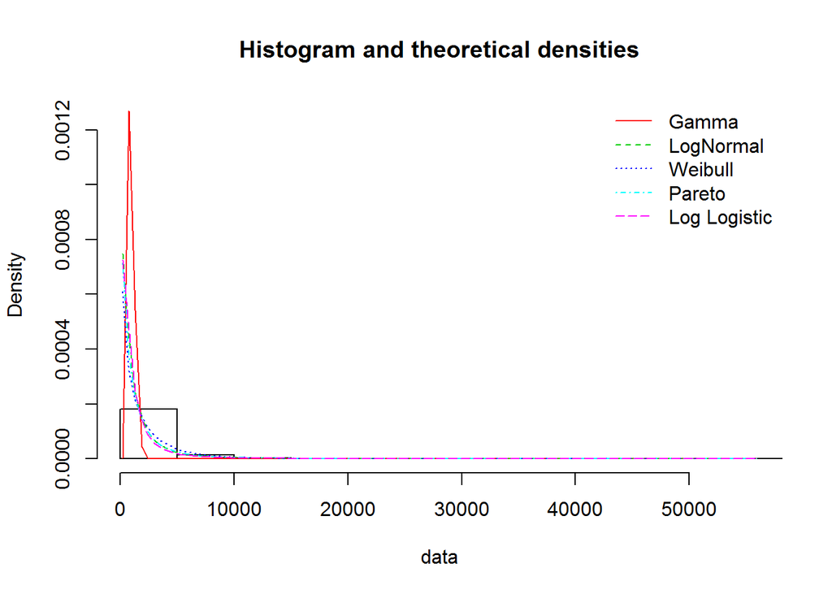

```r
  PlotLegend <- c("Gamma", "LogNormal", "Weibull", "Pareto", "Log Logistic")
  denscomp(list(cpGamma, cpLogNorm, cpWeibull, cpPareto, cpLogLogist), legendtext=PlotLegend)
```

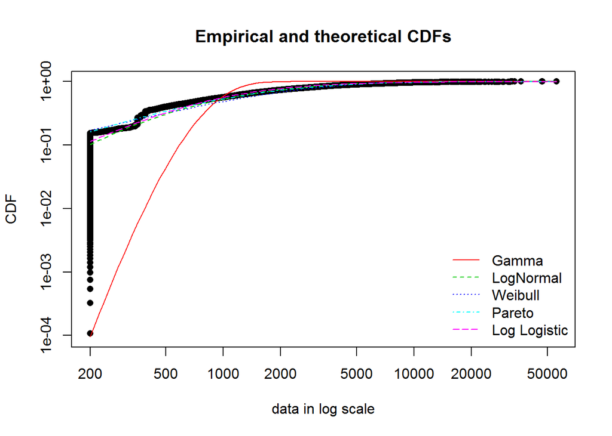

```r
  cdfcomp(list(cpGamma, cpLogNorm, cpWeibull, cpPareto, cpLogLogist), xlogscale=TRUE, ylogscale=TRUE, legendtext=PlotLegend)
```

```r
  gofstat(list(cpGamma, cpLogNorm, cpWeibull, cpPareto, cpLogLogist), fitnames=PlotLegend)
```

```
## Goodness-of-fit statistics
##                                    Gamma  LogNormal     Weibull     Pareto
## Kolmogorov-Smirnov statistic   0.3568693  0.1021038   0.1704634  0.1628852
## Cramer-von Mises statistic   208.8744765 10.5839198  21.3159533 10.7135914
## Anderson-Darling statistic           Inf 72.4949308 139.5430172 87.9284640
##                              Log Logistic
## Kolmogorov-Smirnov statistic    0.1143583
## Cramer-von Mises statistic      8.9456554
## Anderson-Darling statistic     69.8628094
##
## Goodness-of-fit criteria
##                                   Gamma LogNormal  Weibull   Pareto
## Aikake's Information Criterion 163661.9  77708.31 78987.19 78343.71
## Bayesian Information Criterion 163674.8  77721.19 79000.07 78356.58
##                                Log Logistic
## Aikake's Information Criterion     77931.34
## Bayesian Information Criterion     77944.22
```